# Презентация по лабораторной работе №3

Управляющие структуры

Люпп Софья Романовна

1132236039@rudn.ru

Российский университет дружбы народов

2026-10-09

# Информация

## Докладчик

- Люпп Софья Романовна
- студентка группы НКНбд-01-23
- кафедра теории вероятностей и кибербезопасности
- Российский университет дружбы народов им. П. Лумумбы
- [1132236039@rudn.ru]
- https://github.com/srluipp

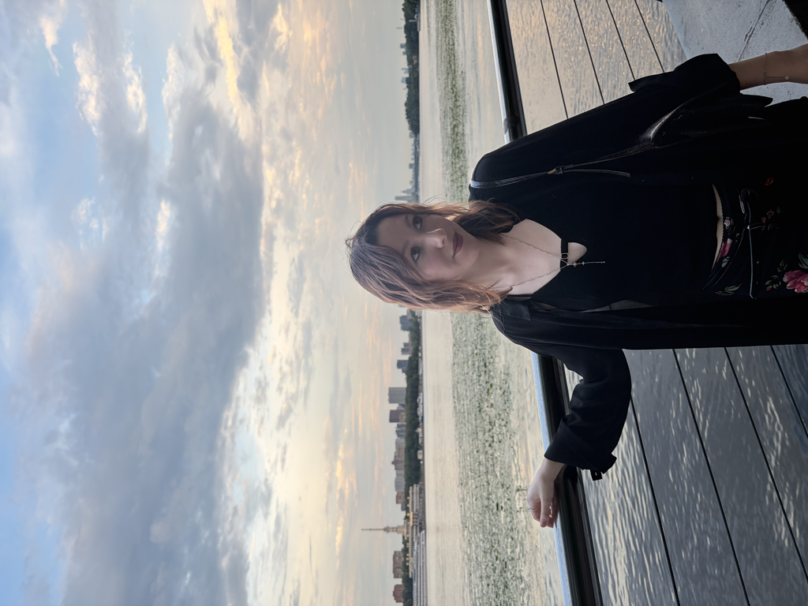

# Вводная часть

## Актуальность

Julia актуальна как инструмент для научных вычислений, финансового моделирования, искусственного интеллекта, вычислений в области инженерии и физики, благодаря своей высокой производительности, простоте синтаксиса и гибкости в работе с массивами и параллельным программированием

## Объект и предмет исследования

Язык программирования Julia и среда JupyterLab

## Цели и задачи

Основная цель работы — освоить применение циклов функций и сторонних для Julia пакетов для решения задач линейной алгебры и работы с матрицами.

# Выполнение лабораторной работы

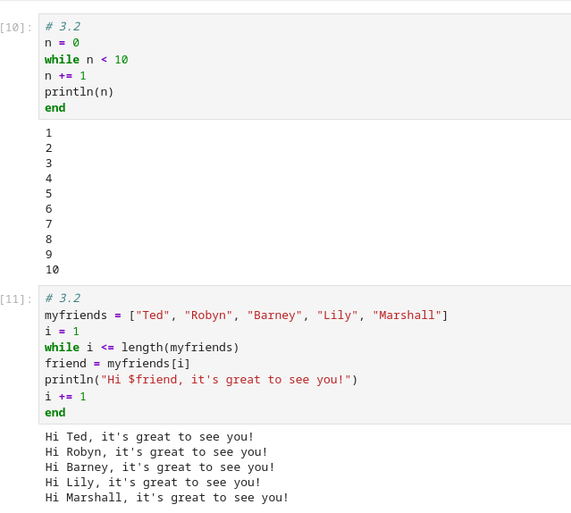

## Задания лабораторной работы

Воспроизвожу еще один пример с for и пример работы с матрицами через индексы i j (рис. 2)

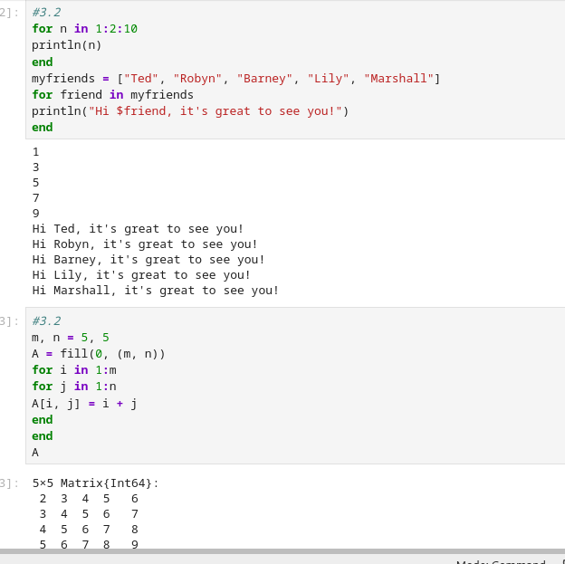

Рисунок 2: Матрицы

## Задания лабораторной работы

Далее привожу примеры вывода матриц разными способами (рис. 3)

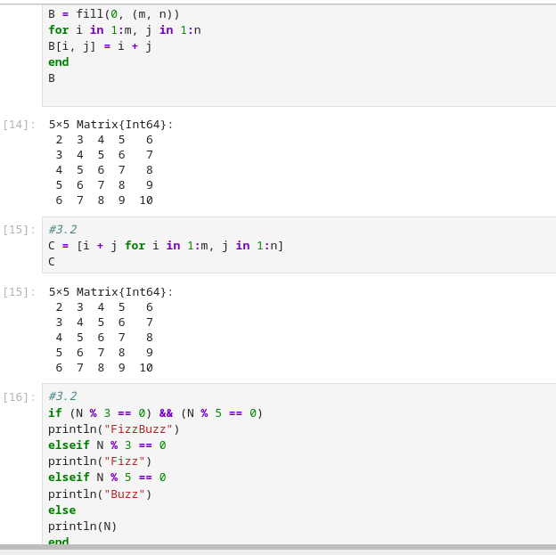

Рисунок 3: Матрицы

## Задания лабораторной работы

Привожу пример работы функций, а так же работы sort (рис. 4)

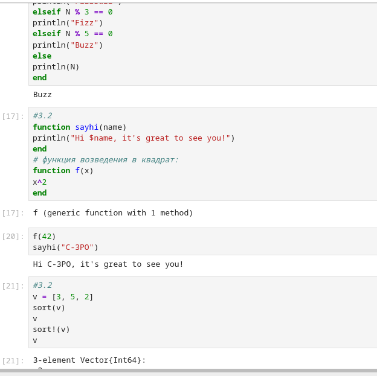

Рисунок 4: функции

## Задания лабораторной работы

Выполняю пример функций для вывода матриц (рис. 5).

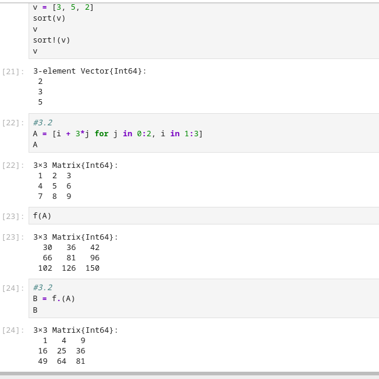

Рисунок 5: Матрицы

## Задания лабораторной работы

Выполняю пример функций для вывода матриц (рис. 6)

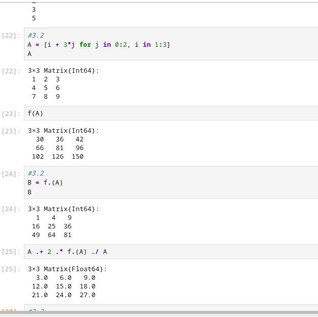

Рисунок 6: Матрицы

## Задания лабораторной работы

[figure not shown]

Рисунок 7: Example

## Задания лабораторной работы

Тмк же добавляю пакет Colors (рис. 8).

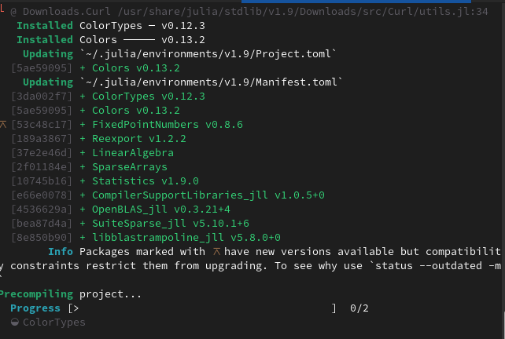

Рисунок 8: Colors

## Задания лабораторной работы

Повторяю пример с выводом цветовой палитры (рис. 9).

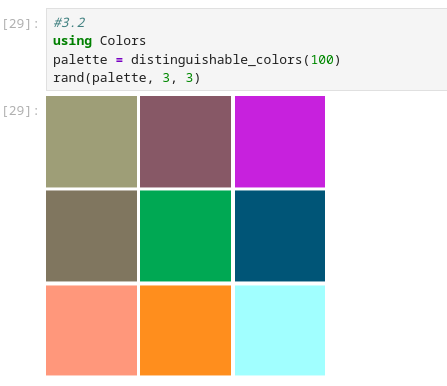

Рисунок 9: Цветовая палитра

## Задания самостоятельной работы (№1)

Используя циклы while и for вывожу на экран целые числа от 1 до 100 и печатаю их квадраты;создаю словарь squares и массив squares_arr, содержащий квадраты всех чисел от 1 до 100 (рис. 10)

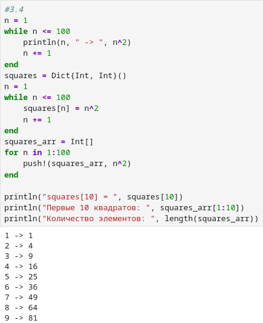

Рисунок 10: 1

## Задания самостоятельной работы (№1)

(рис. 11)

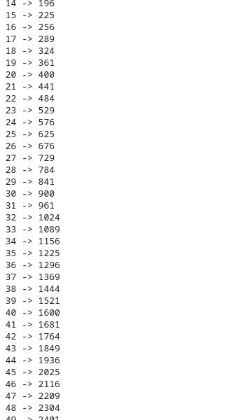

Рисунок 11: 1

## Задания самостоятельной работы (№1)

(рис. 12)

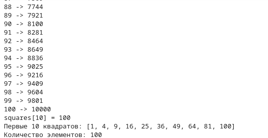

Рисунок 12: 1

## №2 и №3

Пишу условный оператор, который печатает число, если число чётное, и строку «нечётное», если число нечётное. Использую тернарный оператор. Для задания 3 пишу простое условие (функцию) добавление плюс одного значения (рис. 13)

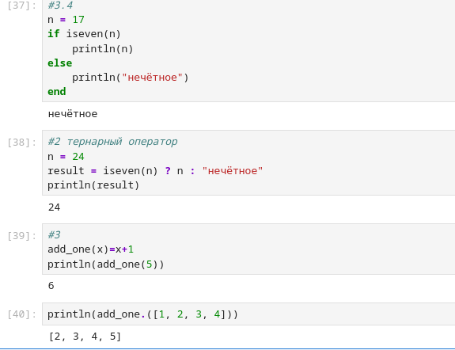

Рисунок 13: 3.9

## №4

Использую map() или broadcast() для задания матрицы 𝐴, каждый элемент которой увеличивается на единицу по сравнению с предыдущим (рис. 14)

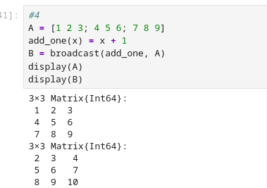

Рисунок 14: 3.10

## №5

Задаю матрицу по заданию и возвожу ее в куб (рис. 15)

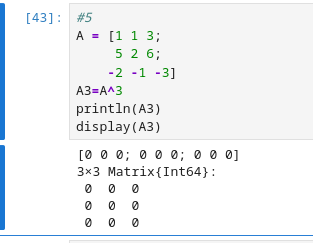

Рисунок 15: 5

## №5

(рис. 16)

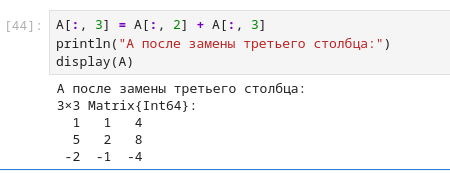

Рисунок 16: 5

## №6

Создаю матрицу 𝐵 с элементами 𝐵𝑖1 = 10, 𝐵𝑖2 = −10, 𝐵𝑖3 = 10, 𝑖 = 1, 2, … , 15. Вычисляю матрицу 𝐶 = 𝐵𝑇𝐵 (рис. 17)

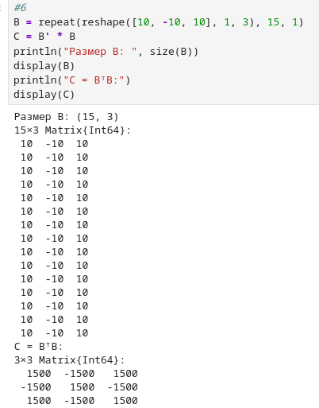

Рисунок 17: 6

## 7

Создаю матрицу 𝑍 размерности 6 × 6, все элементы которой равны нулю, и матрицу 𝐸, все элементы которой равны 1. Используя цикл while или for и закономерности расположения элементов, создаю матрицы размерности 6 × 6 (рис. 18)

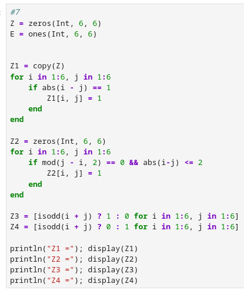

Рисунок 18: 7

## 7

(рис. 19)

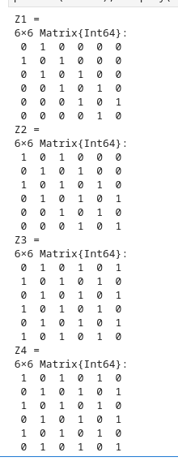

Рисунок 19: 7

## №8

Работаю с функцией outer() (это матричное умножение с возможностью изменить применяемую операцию). Пишу свою функцию, аналогичную функции outer() с интерфейсом: outer(x,y,operation) (рис. 20)

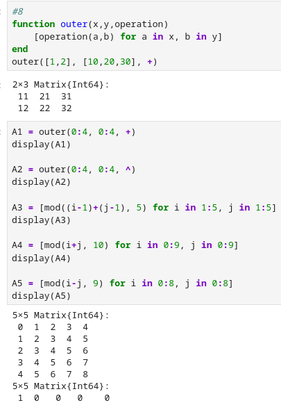

Рисунок 20: outer

## №8

(рис. 21)

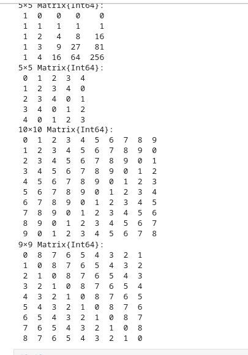

Рисунок 21: outer

## №9

Решаю систему линейных уравнений с 5 неизвестными с помощью уравнения Ax = 𝑦 (рис. 22)

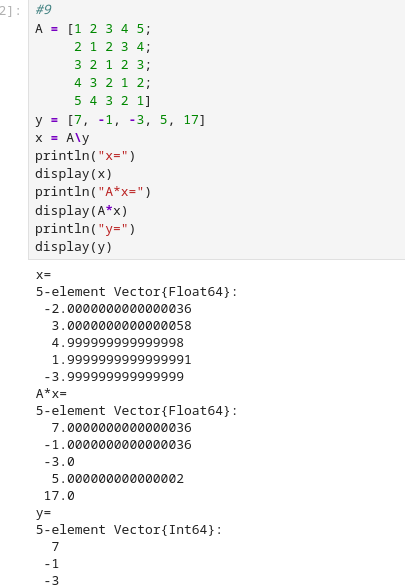

Рисунок 22: СЛАУ

## №10

Создаю матрицу 𝑀 размерности 6 × 10, элементами которой являются целые числа, выбранные случайным образом с повторениями из совокупности 1, 2, … , 10 и решаю еще некоторые условия по заданию (рис. 23)

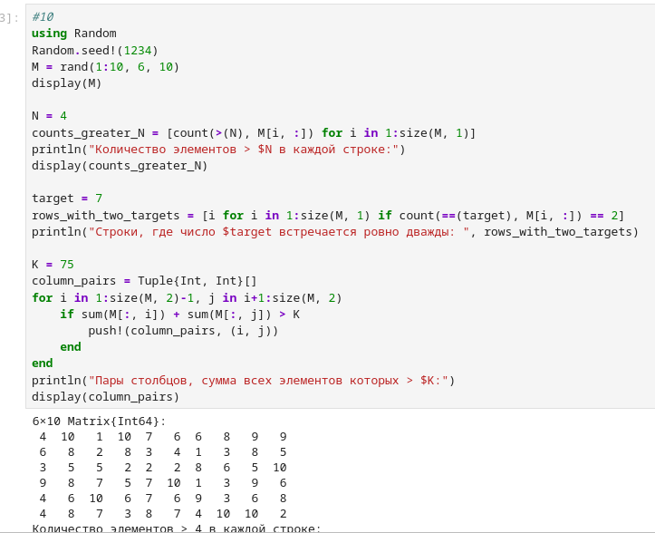

Рисунок 23: 10

## №10

(рис. 24)

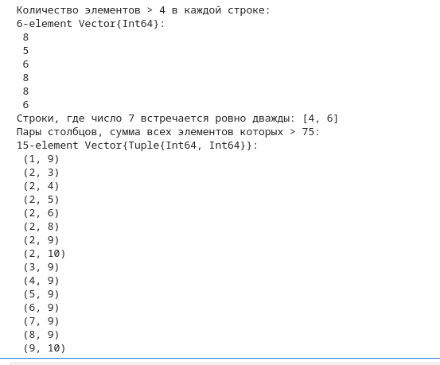

Рисунок 24: 10

# Выводы

В результате получился ipynb файл с выполненными заданиями на языке Julia. В ходе работы я освоила применение циклов функций и сторонних для Julia пакетов для решения задач линейной алгебры и работы с матрицами.